# İST347 — Merkezi Limit Teoremi Simülasyon Raporu

Yazar

efekcss

Yayınlanma Tarihi

17 Kasım 2026

## 1. Giriş ve Teorik Çerçeve

Bu çalışmada, **sağa çarpık** bir kitle dağılımından çekilen farklı büyüklükteki örneklemlerin ($n$) ortalamalarının dağılımı incelenmektedir.

**Merkezi Limit Teoremi’ne (MLT)** göre; kitlenin dağılım şekli ne olursa olsun (çarpık veya kesikli olsa bile), örneklem büyüklüğü ($n$) arttıkça örneklem ortalamalarının ($\bar{X}$) dağılımı **Normal Dağılıma** yaklaşır.

## Simülasyon Parametreleri

- **Kitle:** $0$ ile $10$ puan arası dart atışları ($0$ puana $10$ atış, $10$ puana $0$ atış sıklığı).
- **Örneklem Büyüklükleri (**$n$): $1$, $3$ ve $5$ atış.
- **Simülasyon Tekrar Sayısı:** Her senaryo için $100$ tekrar.

## 2. Kitlenin Oluşturulması

Dart oyunundaki puanlar ve sıklıklar tanımlanarak sağa çarpık kitle vektörü oluşturulmuştur:

```r
# Puanlar (0'dan 10'a) ve tersten atış frekansları (10'dan 0'a)
puanlar <- 0:10
frekanslar <- 10:0

# Kitle vektörünün rep() ile türetilmesi
kitle <- rep(puanlar, frekanslar)

# Kitle özet istatistikleri
kitle_ort <- mean(kitle)
kitle_ss <- sd(kitle)
```

Kitlenin ortalaması 3 ve standart sapması 2.47 olarak hesaplanmıştır.

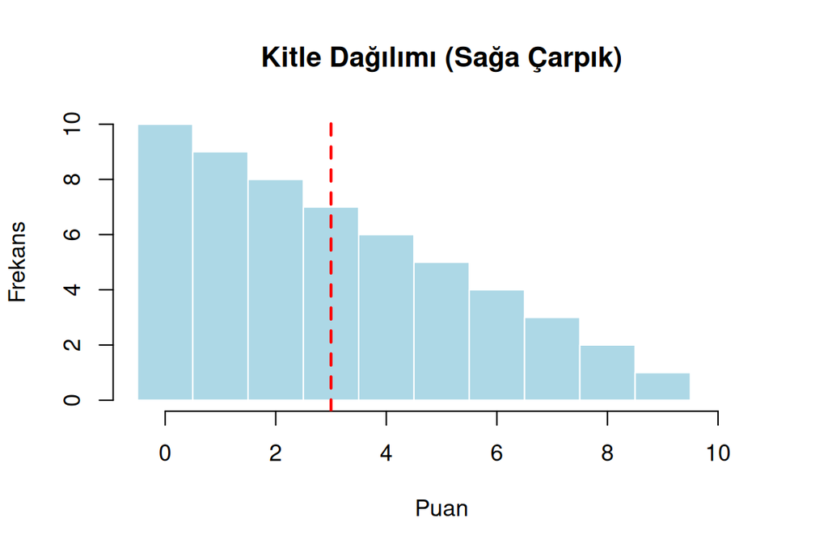

Şekil 1: Kitle Dağılımı (Sağa Çarpık)

```r
hist(kitle, breaks = seq(-0.5, 10.5, 1), col = "lightblue", border = "white",
     main = "Kitle Dağılımı (Sağa Çarpık)",
     xlab = "Puan", ylab = "Frekans")
abline(v = kitle_ort, col = "red", lwd = 2, lty = 2)
```

## 3. Simülasyonun Çalıştırılması ($n = 1, 3, 5$)

Rastgele sayı üretiminde tekrarlanabilirliği sağlamak amacıyla `set.seed(26)` fonksiyonu kullanılmış (26 Eskişehir <3) ve `replicate()` ile $100$’er kez örneklem çekilerek ortalamaları alınmıştır:

```r
set.seed(26)
n_tekrar <- 100

# n = 1, 3 ve 5 için 100'er kez ortalama hesaplama
ort_n1 <- replicate(n_tekrar, mean(sample(kitle, size = 1, replace = TRUE)))
ort_n3 <- replicate(n_tekrar, mean(sample(kitle, size = 3, replace = TRUE)))
ort_n5 <- replicate(n_tekrar, mean(sample(kitle, size = 5, replace = TRUE)))

# Verileri Quarto ve ggplot2 için düzenleme
sim_veri <- data.frame(
  n1 = ort_n1,
  n3 = ort_n3,
  n5 = ort_n5
) |>
  pivot_longer(cols = everything(), names_to = "Orneklem_Boyutu", values_to = "Ortalama") |>
  mutate(Orneklem_Boyutu = factor(Orneklem_Boyutu,
                                  levels = c("n1", "n3", "n5"),
                                  labels = c("n = 1 Atış", "n = 3 Atış", "n = 5 Atış")))
```

## 4. Örneklem Ortalamalarının Dağılımı ve Görselleştirme

Elde edilen $100$’er adet ortalamanın dağılımı paneller (`facet_wrap`) halinde karşılaştırılmıştır:

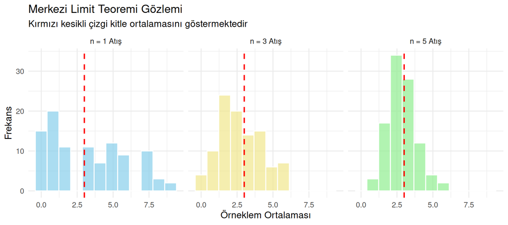

Şekil 2: Farklı Örneklem Büyüklüklerinde Ortalamaların Dağılımı (100 Tekrar)

```r
ggplot(sim_veri, aes(x = Ortalama, fill = Orneklem_Boyutu)) +
  geom_histogram(bins = 12, colour = "white", alpha = 0.7) +
  geom_vline(xintercept = kitle_ort, colour = "red", linetype = "dashed", linewidth = 0.8) +
  facet_wrap(~ Orneklem_Boyutu, nrow = 1) +
  scale_fill_manual(values = c("skyblue", "khaki", "lightgreen")) +
  labs(title = "Merkezi Limit Teoremi Gözlemi",
       subtitle = "Kırmızı kesikli çizgi kitle ortalamasını göstermektedir",
       x = "Örneklem Ortalaması", y = "Frekans") +
  theme_minimal(base_size = 12) +
  theme(legend.position = "none")
```

## 5. Değerlendirme ve Sonuç

```r
# Örneklem ortalamalarının ve standart hatalarının özet tablosu
ozet_tablo <- sim_veri |>
  group_by(Orneklem_Boyutu) |>
  summarise(
    `Ortalamaların Ortalaması` = round(mean(Ortalama), 3),
    `Standart Hata (SH)` = round(sd(Ortalama), 3)
  )

knitr::kable(ozet_tablo, caption = "Örneklem Büyüklüğüne Göre İstatistikler")
```

Tablo 1: Örneklem Büyüklüğüne Göre İstatistikler

| Orneklem_Boyutu | Ortalamaların Ortalaması | Standart Hata (SH) |
| --- | --- | --- |
| n = 1 Atış | 3.290 | 2.583 |
| n = 3 Atış | 2.757 | 1.431 |
| n = 5 Atış | 2.892 | 0.979 |

Yapılan simülasyon sonucunda:

1. **Yansızlık:** Örneklem büyüklüğü ne olursa olsun, örneklem ortalamalarının ortalaması kitle ortalamasına oldukça yakındır.
2. **Standart Hata:** Örneklem büyüklüğü ($n$) arttıkça standart hata ($SH = s/\sqrt{n}$) küçülmüş ve ortalamaların yayılımı daralmıştır.
3. **Normalleşme:** Kitle sağa çarpık olmasına rağmen, $n$ sayısı $1$’den $5$’e doğru büyüdükçe ortalamaların dağılımı simetrikleşmiş ve Normal Dağılım çan eğrisi formuna yaklaşmıştır.